# Final Project

Author

Leo Camino, ltc31

Published

2025-12-05

## Loading and understanding the data

I will be recreating the figure from the paper [“Genetics of yellow-orange color variation in a pair of sympatric sulphur butterflies”](https://doi.org/10.1016/j.celrep.2023.112820) by *Hanly et. al (2023)*. Especifically, I will recreate [this figure](https://www.cell.com/cms/10.1016/j.celrep.2023.112820/asset/6a135dcb-1a69-46e6-8eb7-093adf3b5c50/main.assets/gr1_lrg.jpg), specifically I will recreate panel A, B, E, F and G.

First, I will set the base directory. **Please, consider** that you will have to change it to the place where you located the data folder in your particular case.

```r
#base directory
base_dir <- ("C:/Users/leoto/Desktop/data")
```

Then, I will define the names of the folders that contain the .jpg files that I will use for each brood analyzed:

```r
pop_folder <- c(
  "DFW_49",  # Population 1
  "DFW_75",  # Population 2
  "DFW_79",   # Population 3
  "test" # A folder to make some diagnostic with only 10 random jpg
)

DFW_49 <- c("DFW_49")
DFW_75 <- c("DFW_75")
DFW_79 <- c("DFW_79")
Test <- c("test")
```

Now, I will make a vector with all the paths:

```r
pop_paths <- file.path(base_dir, pop_folder)
dfw_49 <- file.path(base_dir, DFW_49)
dfw_75 <- file.path(base_dir, DFW_75)
dfw_79 <- file.path(base_dir, DFW_79)
test <- file.path(base_dir, Test)
```

We need a function that gets all JPG files from a specific folder, for that reason, I will create a function called `get_jpg_files` :

```r
get_jpg_files <- function(folder_path) {
  list.files(folder_path,
             pattern = "\\.jpg$|\\.jpeg$|\\.JPG$",  # This makes sure we take .jpg files in any isoform
             full.names = TRUE,       # This line will help us returning full paths
             recursive = FALSE)       # If there was a subfolder, we will ignore it with this line.
}
```

Now, we will make a code where we get files for each brood using `pop_folder`

```r
pop_files <- list()
for (i in seq_along(pop_folder)) {
  pop_name <- pop_folder[i]
  pop_path <- pop_paths[i]

  files <- get_jpg_files(pop_path)
  pop_files[[pop_name]] <- files
}
```

I did not participate in the paper, so I don’t really know how many individuals are on each brood. I could count them on the figure, but I decided to make a chunk of code that tells me the number of individuals photographed instead. I think that is more elegant.

```r
cat("=== Final Image Count ===\n")
```

```
=== Final Image Count ===
```

```r
for (pop in pop_folder) {
  cat(pop, ":", length(pop_files[[pop]]), "images\n")
}
```

```
DFW_49 : 148 images
DFW_75 : 198 images
DFW_79 : 115 images
test : 10 images
```

```r
cat("Total:", sum(sapply(pop_files, length)), "images\n")
```

```
Total: 471 images
```

Cool! We have 148 individuals for DFW_49, 198 for DFW_75, and 115 for DFW_79. This is very exciting.

## Color analysis

### Libraries

For now, we have understood better the data structure and also made sure our code is able to retrieve the information of the images. We can proceed with the actual decomposition of the wing colors using the `color distance` package. First thing we will do here is loading the actual libraries that we will use to manipulate color, extract the data, wrangle the data and plot the results.

```r
# Load required packages for color analysis
library(colordistance)  # For color space analysis
library(ggplot2)        # For plotting
library(dplyr)          # For data manipulation
library(purrr)          # For functional programming
library(stringr)        # For string manipulation
library(ggridges)       # For creating joy plots
library(tidyr)          # For data wrangling
library(patchwork)      # For figure combination
library(rgl)            # For transforming colordistance figures to png
```

### Lab space decomposition

This will be hard, but let’s create a function that processes a single butterfly image and extracts the yellow color information. Please, consider that in the CIEL*a*b spaces:

- a is the dimension where red and green hues are balanced.
- b is the dimension where the blue and yellow hues are balanced.
- L is the light intensity (white vs black).

In this case, our mission is to first produce the CIEL*a*b space of each photo using the `colordistance` package, and then figure out how to decompose the 3D space to extract the b values.

```r
# Simple function to extract b* values from an image
extract_b_values <- function(img_path) {
  # Load the image
  img <- colordistance::loadImage(
    img_path,
    CIELab = TRUE,
    ref.white = "D65",
    sample.size = 10000  # I am taking 10 thousand random pixels from the image for analysis. It is a good number. Takes a while.
  )

  # The next line is the most important in the whole file. It extracts the specific "b" space from the CIEL*a*b space.
  lab_df <- img$filtered.lab.2d

  #I will also add some additional useful functions for later, such as butterfly ID extraction,
  butterfly_id <- str_extract(filename, "\\d{3}(?=DFW)")

  # Extract brood from filename: "00-49-001DFW.jpg"
  filename <- basename(img_path)

  # Extract population (49, 75, or 79)
  population <- str_extract(filename, "(?<=-)\\d{2}(?=-)")

  # Return data frame with b* values
  data.frame(
    butterfly_id = butterfly_id,
    population = population,
    b_value = lab_df$b  # b* values (blue-yellow axis)
  )
}
```

### Understanding the 3D space

Here I want to test if the last chunk was able to actually extract the Lab color spaces of the .jpg files. Let’s take a look first plotting the 3D Lab space using the function `colordistance::plotPixels()`.

First, let’s establish the individual 001 from brood 49 as the test file:

```r
test_file <- pop_files[["test"]][1]
```

Now we can proceed to plot the L*a*b 3D color space. I will create a function that can instantly produce a 3D L*a*b figure using a function called `Lab_plot` :

```
From reference white:
To reference white: D65
```

```
Converting 10000 randomly selected pixel(s) from sRGB color space to Lab color space
```

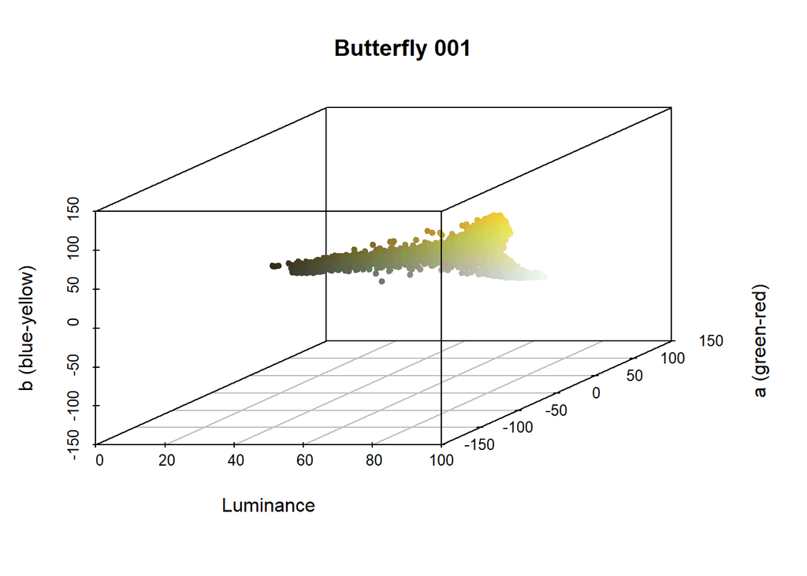

```r
Lab_plot <- function(img_path) {
  filename <- basename(img_path)
  butterfly_id <- str_extract(filename, "\\d{3}(?=DFW)")

  # 3D CIELab space plot
  colordistance::plotPixels(
    img_path,
    color.space = "lab",
    ref.white = "D65",
    n = 10000, #We will take 20 thousand random pixels here too.
    main = paste("Butterfly", butterfly_id),
    ylim = c(-150, 150),
    zlim = c(-150, 150)
  )
}

Lab_plot(test_file)
```

What we see here is a very nice plot of the three dimensions of color decomposition in the L*a*b space. In fact, this is the type of figure they use for **A)** panel on their *Figure 1*, however, the individual 001 from brood 49 is not the correct one.

### Function to load an image and extract RGB (CIEL*a*b) pixels from it

First, I will create a function that loads the photos from the colordistance package that

- Takes ten thousand random pixels to analyze.
- Removes the background noise from white pixels using a threshold.
- Extracts the L*a*b values of the ten thousand random pixels.
- Removes the black and brown pixels from the photos (*Colias* butterflies have a black band on their dorsal forewings that we don’t want to analyze).
- Returns a data frame for the specific b values. **Note:** when trying to do this, I noticed even though the authors of the paper say they masked for the “b” space that comprehends blue-yellow balance, what they actually plotted were the hues of all the different yellows present on the “L” Luminance space. In that sense, I will do the same.

```r
extract_b_values <- function(img_path) {
  # Load the image with colordistance
  img <- colordistance::loadImage(
    img_path,
    CIELab = TRUE,
    ref.white = "D65", #calibrates the whites
    sample.size = 10000, #Extracts ten thousand random pixels
    lower = c(0.7, 0.8, 0.8), #filter for white background
    upper = c(1, 1, 1)
  )

  # Extract L*a*b dataframe
  lab <- img$filtered.lab.2d #I create the main CIEL*a*b dataframe here.

  # Apply a yellow mask
  yellow_mask <- lab$L >= 70 & lab$L <= 100 &
                 lab$b >= 20 & lab$b <= 80 &
                 lab$a >= -140 & lab$a <= 140

  # Keep only yellow pixels
  yellow_lab <- lab[yellow_mask, ]

  # Modify the name of the file so we get the individual
  clean_name <- sub("D\\.jpg$", "", basename(img_path))

  # Return data frame of ONLY yellow b* values
  data.frame(
    sample = clean_name,
    b_value = yellow_lab$L
  )
}
```

Now that my `extract_b_values` function is ready, I have to load the files. To do this, I will use the paths I already created some chunks before. Additionally, I will find the highest yellow score and organize the histograms by this parameter using dplyr.

### Test folder

```r
img_files_test <- list.files(
  path = test,
  pattern = "\\.jpg$",
  full.names = TRUE
)

b_data_test <- purrr::map_dfr(img_files_test, extract_b_values, .progress = TRUE)
```

[output not shown]

[output not shown]

[output not shown]

[output not shown]

[output not shown]

[output not shown]

[output not shown]

[output not shown]

[output not shown]

[output not shown]

[output not shown]

[output not shown]

[output not shown]

[output not shown]

[output not shown]

[output not shown]

[output not shown]

[output not shown]

[output not shown]

[output not shown]

[output not shown]

```r
sample_order <- b_data_test |>
  dplyr::group_by(sample) |>
  dplyr::summarize(med = median(b_value, na.rm = TRUE)) |>
  dplyr::arrange(desc(med)) |>
  dplyr::pull(sample)

b_data_test$sample <- factor(b_data_test$sample, levels = sample_order)

#Here I established the range to draw all the following histograms
range(b_data_test$b_value)
```

```
[1] 70.00007 95.11078
```

Let’s test very quickly using this code to graph a joyplot with our b and L values.

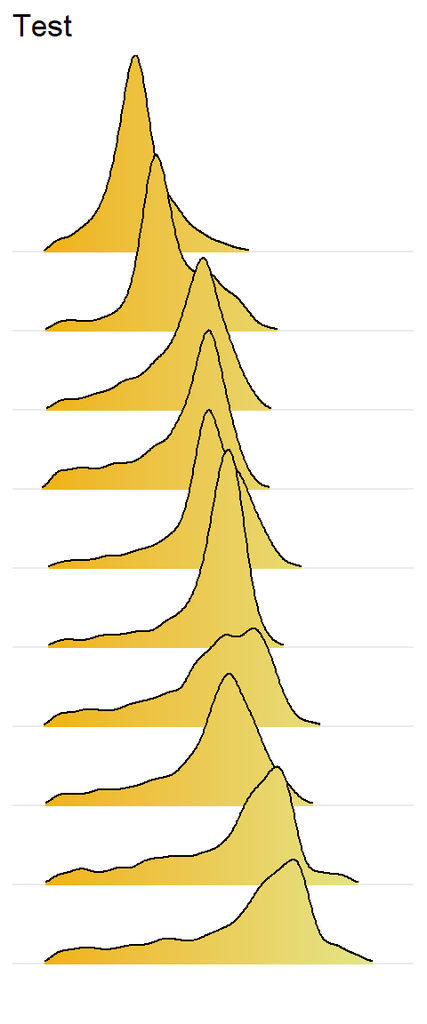

```r
ggplot(b_data_test, aes(x = b_value, y = sample, fill = after_stat(x))) +
  geom_density_ridges_gradient(scale = 2.5, rel_min_height = 0.01, color = "black") +
  scale_fill_gradient(low = "#EFB001", high = "#DFE990") +
  scale_x_continuous(breaks = 50)+
  theme_minimal() +
  theme(legend.position = "none",
  axis.title.y = element_blank(),
  axis.text.y  = element_blank(),
  axis.ticks.y = element_blank(),
  axis.line.y  = element_blank(),
  axis.line.x = element_blank(),
  axis.title.x = element_blank()
)+
  labs(
    title = "Test",
    fill = "b*"
  )
```

Amazing, the joyplots are working, as well as the gradient and the organization of peaks based on the maximum yellow score. In the original figure they place the joyplots in a descending way, from higher scores (yellow) to lower scores (orange). We will do the opposite just to explore the aesthetics of the same figure organized in another way.

### Broods 49

```r
img_files_49 <- list.files(
  path = dfw_49,
  pattern = "\\.jpg$",
  full.names = TRUE
)

b_data_49 <- purrr::map_dfr(img_files_49, extract_b_values, .progress = TRUE)
```

[output not shown]

[output not shown]

[output not shown]

[output not shown]

[output not shown]

[output not shown]

[output not shown]

[output not shown]

[output not shown]

[output not shown]

[output not shown]

[output not shown]

[output not shown]

[output not shown]

[output not shown]

[output not shown]

[output not shown]

[output not shown]

[output not shown]

[output not shown]

[output not shown]

[output not shown]

[output not shown]

[output not shown]

[output not shown]

[output not shown]

[output not shown]

[output not shown]

[output not shown]

[output not shown]

[output not shown]

[output not shown]

[output not shown]

[output not shown]

[output not shown]

[output not shown]

[output not shown]

[output not shown]

[output not shown]

[output not shown]

[output not shown]

[output not shown]

[output not shown]

[output not shown]

[output not shown]

[output not shown]

[output not shown]

[output not shown]

[output not shown]

[output not shown]

[output not shown]

[output not shown]

[output not shown]

[output not shown]

[output not shown]

[output not shown]

[output not shown]

[output not shown]

[output not shown]

[output not shown]

[output not shown]

[output not shown]

[output not shown]

[output not shown]

[output not shown]

[output not shown]

[output not shown]

[output not shown]

[output not shown]

[output not shown]

[output not shown]

[output not shown]

[output not shown]

[output not shown]

[output not shown]

[output not shown]

[output not shown]

[output not shown]

[output not shown]

[output not shown]

[output not shown]

[output not shown]

[output not shown]

[output not shown]

[output not shown]

[output not shown]

[output not shown]

[output not shown]

[output not shown]

[output not shown]

[output not shown]

[output not shown]

[output not shown]

[output not shown]

[output not shown]

[output not shown]

[output not shown]

[output not shown]

[output not shown]

[output not shown]

[output not shown]

[output not shown]

[output not shown]

[output not shown]

[output not shown]

[output not shown]

[output not shown]

[output not shown]

[output not shown]

[output not shown]

[output not shown]

[output not shown]

[output not shown]

[output not shown]

[output not shown]

[output not shown]

[output not shown]

[output not shown]

[output not shown]

[output not shown]

[output not shown]

[output not shown]

[output not shown]

[output not shown]

[output not shown]

[output not shown]

[output not shown]

[output not shown]

[output not shown]

[output not shown]

[output not shown]

[output not shown]

[output not shown]

[output not shown]

[output not shown]

[output not shown]

[output not shown]

[output not shown]

[output not shown]

[output not shown]

[output not shown]

[output not shown]

[output not shown]

[output not shown]

[output not shown]

[output not shown]

[output not shown]

[output not shown]

[output not shown]

[output not shown]

[output not shown]

[output not shown]

[output not shown]

[output not shown]

[output not shown]

[output not shown]

[output not shown]

[output not shown]

[output not shown]

[output not shown]

[output not shown]

[output not shown]

[output not shown]

[output not shown]

[output not shown]

[output not shown]

[output not shown]

[output not shown]

[output not shown]

[output not shown]

[output not shown]

[output not shown]

[output not shown]

[output not shown]

[output not shown]

[output not shown]

[output not shown]

[output not shown]

[output not shown]

[output not shown]

[output not shown]

[output not shown]

[output not shown]

[output not shown]

[output not shown]

[output not shown]

[output not shown]

[output not shown]

[output not shown]

[output not shown]

[output not shown]

[output not shown]

[output not shown]

[output not shown]

[output not shown]

[output not shown]

[output not shown]

[output not shown]

[output not shown]

[output not shown]

[output not shown]

[output not shown]

[output not shown]

[output not shown]

[output not shown]

[output not shown]

[output not shown]

[output not shown]

[output not shown]

[output not shown]

[output not shown]

[output not shown]

[output not shown]

[output not shown]

[output not shown]

[output not shown]

[output not shown]

[output not shown]

[output not shown]

[output not shown]

[output not shown]

[output not shown]

[output not shown]

[output not shown]

[output not shown]

[output not shown]

[output not shown]

[output not shown]

[output not shown]

[output not shown]

[output not shown]

[output not shown]

[output not shown]

[output not shown]

[output not shown]

[output not shown]

[output not shown]

[output not shown]

[output not shown]

[output not shown]

[output not shown]

[output not shown]

[output not shown]

[output not shown]

[output not shown]

[output not shown]

[output not shown]

[output not shown]

[output not shown]

[output not shown]

[output not shown]

[output not shown]

[output not shown]

[output not shown]

[output not shown]

[output not shown]

[output not shown]

[output not shown]

[output not shown]

[output not shown]

[output not shown]

[output not shown]

[output not shown]

[output not shown]

[output not shown]

[output not shown]

[output not shown]

[output not shown]

[output not shown]

[output not shown]

[output not shown]

[output not shown]

[output not shown]

[output not shown]

[output not shown]

[output not shown]

[output not shown]

[output not shown]

[output not shown]

[output not shown]

[output not shown]

[output not shown]

[output not shown]

[output not shown]

[output not shown]

[output not shown]

[output not shown]

[output not shown]

[output not shown]

[output not shown]

[output not shown]

[output not shown]

[output not shown]

[output not shown]

[output not shown]

[output not shown]

[output not shown]

[output not shown]

[output not shown]

[output not shown]

[output not shown]

[output not shown]

[output not shown]

[output not shown]

[output not shown]

[output not shown]

[output not shown]

[output not shown]

[output not shown]

[output not shown]

[output not shown]

[output not shown]

[output not shown]

[output not shown]

[output not shown]

[output not shown]

[output not shown]

[output not shown]

[output not shown]

[output not shown]

[output not shown]

[output not shown]

[output not shown]

[output not shown]

[output not shown]

[output not shown]

[output not shown]

```r
sample_order <- b_data_49 |>
  dplyr::group_by(sample) |>
  dplyr::summarize(med = median(b_value, na.rm = TRUE)) |>
  dplyr::arrange(desc(med)) |>
  dplyr::pull(sample)

b_data_49$sample <- factor(b_data_49$sample, levels = sample_order)

#Here I established the range to draw all the following histograms
range(b_data_49$b_value)
```

```
[1] 70.00007 95.66259
```

### Broods 75

```r
img_files_75 <- list.files(
  path = dfw_75,
  pattern = "\\.jpg$",
  full.names = TRUE
)

b_data_75 <- purrr::map_dfr(img_files_75, extract_b_values, .progress = TRUE)
```

[output not shown]

[output not shown]

[output not shown]

[output not shown]

[output not shown]

[output not shown]

[output not shown]

[output not shown]

[output not shown]

[output not shown]

[output not shown]

[output not shown]

[output not shown]

[output not shown]

[output not shown]

[output not shown]

[output not shown]

[output not shown]

[output not shown]

[output not shown]

[output not shown]

[output not shown]

[output not shown]

[output not shown]

[output not shown]

[output not shown]

[output not shown]

[output not shown]

[output not shown]

[output not shown]

[output not shown]

[output not shown]

[output not shown]

[output not shown]

[output not shown]

[output not shown]

[output not shown]

[output not shown]

[output not shown]

[output not shown]

[output not shown]

[output not shown]

[output not shown]

[output not shown]

[output not shown]

[output not shown]

[output not shown]

[output not shown]

[output not shown]

[output not shown]

[output not shown]

[output not shown]

[output not shown]

[output not shown]

[output not shown]

[output not shown]

[output not shown]

[output not shown]

[output not shown]

[output not shown]

[output not shown]

[output not shown]

[output not shown]

[output not shown]

[output not shown]

[output not shown]

[output not shown]

[output not shown]

[output not shown]

[output not shown]

[output not shown]

[output not shown]

[output not shown]

[output not shown]

[output not shown]

[output not shown]

[output not shown]

[output not shown]

[output not shown]

[output not shown]

[output not shown]

[output not shown]

[output not shown]

[output not shown]

[output not shown]

[output not shown]

[output not shown]

[output not shown]

[output not shown]

[output not shown]

[output not shown]

[output not shown]

[output not shown]

[output not shown]

[output not shown]

[output not shown]

[output not shown]

[output not shown]

[output not shown]

[output not shown]

[output not shown]

[output not shown]

[output not shown]

[output not shown]

[output not shown]

[output not shown]

[output not shown]

[output not shown]

[output not shown]

[output not shown]

[output not shown]

[output not shown]

[output not shown]

[output not shown]

[output not shown]

[output not shown]

[output not shown]

[output not shown]

[output not shown]

[output not shown]

[output not shown]

[output not shown]

[output not shown]

[output not shown]

[output not shown]

[output not shown]

[output not shown]

[output not shown]

[output not shown]

[output not shown]

[output not shown]

[output not shown]

[output not shown]

[output not shown]

[output not shown]

[output not shown]

[output not shown]

[output not shown]

[output not shown]

[output not shown]

[output not shown]

[output not shown]

[output not shown]

[output not shown]

[output not shown]

[output not shown]

[output not shown]

[output not shown]

[output not shown]

[output not shown]

[output not shown]

[output not shown]

[output not shown]

[output not shown]

[output not shown]

[output not shown]

[output not shown]

[output not shown]

[output not shown]

[output not shown]

[output not shown]

[output not shown]

[output not shown]

[output not shown]

[output not shown]

[output not shown]

[output not shown]

[output not shown]

[output not shown]

[output not shown]

[output not shown]

[output not shown]

[output not shown]

[output not shown]

[output not shown]

[output not shown]

[output not shown]

[output not shown]

[output not shown]

[output not shown]

[output not shown]

[output not shown]

[output not shown]

[output not shown]

[output not shown]

[output not shown]

[output not shown]

[output not shown]

[output not shown]

[output not shown]

[output not shown]

[output not shown]

[output not shown]

[output not shown]

[output not shown]

[output not shown]

[output not shown]

[output not shown]

[output not shown]

[output not shown]

[output not shown]

[output not shown]

[output not shown]

[output not shown]

[output not shown]

[output not shown]

[output not shown]

[output not shown]

[output not shown]

[output not shown]

[output not shown]

[output not shown]

[output not shown]

[output not shown]

[output not shown]

[output not shown]

[output not shown]

[output not shown]

[output not shown]

[output not shown]

[output not shown]

[output not shown]

[output not shown]

[output not shown]

[output not shown]

[output not shown]

[output not shown]

[output not shown]

[output not shown]

[output not shown]

[output not shown]

[output not shown]

[output not shown]

[output not shown]

[output not shown]

[output not shown]

[output not shown]

[output not shown]

[output not shown]

[output not shown]

[output not shown]

[output not shown]

[output not shown]

[output not shown]

[output not shown]

[output not shown]

[output not shown]

[output not shown]

[output not shown]

[output not shown]

[output not shown]

[output not shown]

[output not shown]

[output not shown]

[output not shown]

[output not shown]

[output not shown]

[output not shown]

[output not shown]

[output not shown]

[output not shown]

[output not shown]

[output not shown]

[output not shown]

[output not shown]

[output not shown]

[output not shown]

[output not shown]

[output not shown]

[output not shown]

[output not shown]

[output not shown]

[output not shown]

[output not shown]

[output not shown]

[output not shown]

[output not shown]

[output not shown]

[output not shown]

[output not shown]

[output not shown]

[output not shown]

[output not shown]

[output not shown]

[output not shown]

[output not shown]

[output not shown]

[output not shown]

[output not shown]

[output not shown]

[output not shown]

[output not shown]

[output not shown]

[output not shown]

[output not shown]

[output not shown]

[output not shown]

[output not shown]

[output not shown]

[output not shown]

[output not shown]

[output not shown]

[output not shown]

[output not shown]

[output not shown]

[output not shown]

[output not shown]

[output not shown]

[output not shown]

[output not shown]

[output not shown]

[output not shown]

[output not shown]

[output not shown]

[output not shown]

[output not shown]

[output not shown]

[output not shown]

[output not shown]

[output not shown]

[output not shown]

[output not shown]

[output not shown]

[output not shown]

[output not shown]

[output not shown]

[output not shown]

[output not shown]

[output not shown]

[output not shown]

[output not shown]

[output not shown]

[output not shown]

[output not shown]

[output not shown]

[output not shown]

[output not shown]

[output not shown]

[output not shown]

[output not shown]

[output not shown]

[output not shown]

[output not shown]

[output not shown]

[output not shown]

[output not shown]

[output not shown]

[output not shown]

[output not shown]

[output not shown]

[output not shown]

[output not shown]

[output not shown]

[output not shown]

[output not shown]

[output not shown]

[output not shown]

[output not shown]

[output not shown]

[output not shown]

[output not shown]

[output not shown]

[output not shown]

[output not shown]

[output not shown]

[output not shown]

[output not shown]

[output not shown]

[output not shown]

[output not shown]

[output not shown]

[output not shown]

[output not shown]

[output not shown]

[output not shown]

[output not shown]

[output not shown]

[output not shown]

[output not shown]

[output not shown]

[output not shown]

[output not shown]

[output not shown]

[output not shown]

[output not shown]

[output not shown]

[output not shown]

[output not shown]

[output not shown]

[output not shown]

[output not shown]

[output not shown]

[output not shown]

[output not shown]

[output not shown]

[output not shown]

[output not shown]

[output not shown]

[output not shown]

[output not shown]

[output not shown]

[output not shown]

[output not shown]

[output not shown]

[output not shown]

[output not shown]

[output not shown]

[output not shown]

[output not shown]

[output not shown]

[output not shown]

[output not shown]

[output not shown]

[output not shown]

[output not shown]

[output not shown]

[output not shown]

[output not shown]

[output not shown]

[output not shown]

[output not shown]

[output not shown]

[output not shown]

[output not shown]

[output not shown]

[output not shown]

[output not shown]

[output not shown]

[output not shown]

[output not shown]

[output not shown]

[output not shown]

[output not shown]

[output not shown]

[output not shown]

[output not shown]

[output not shown]

[output not shown]

[output not shown]

[output not shown]

[output not shown]

```r
sample_order <- b_data_75 |>
  dplyr::group_by(sample) |>
  dplyr::summarize(med = median(b_value, na.rm = TRUE)) |>
  dplyr::arrange(desc(med)) |>
  dplyr::pull(sample)

b_data_75$sample <- factor(b_data_75$sample, levels = sample_order)

#Here I established the range to draw all the following histograms
range(b_data_75$b_value)
```

```
[1] 70.00007 95.24779
```

### Broods 79

```r
img_files_79 <- list.files(
  path = dfw_79,
  pattern = "\\.jpg$",
  full.names = TRUE
)

b_data_79 <- purrr::map_dfr(img_files_79, extract_b_values, .progress = TRUE)
```

[output not shown]

[output not shown]

[output not shown]

[output not shown]

[output not shown]

[output not shown]

[output not shown]

[output not shown]

[output not shown]

[output not shown]

[output not shown]

[output not shown]

[output not shown]

[output not shown]

[output not shown]

[output not shown]

[output not shown]

[output not shown]

[output not shown]

[output not shown]

[output not shown]

[output not shown]

[output not shown]

[output not shown]

[output not shown]

[output not shown]

[output not shown]

[output not shown]

[output not shown]

[output not shown]

[output not shown]

[output not shown]

[output not shown]

[output not shown]

[output not shown]

[output not shown]

[output not shown]

[output not shown]

[output not shown]

[output not shown]

[output not shown]

[output not shown]

[output not shown]

[output not shown]

[output not shown]

[output not shown]

[output not shown]

[output not shown]

[output not shown]

[output not shown]

[output not shown]

[output not shown]

[output not shown]

[output not shown]

[output not shown]

[output not shown]

[output not shown]

[output not shown]

[output not shown]

[output not shown]

[output not shown]

[output not shown]

[output not shown]

[output not shown]

[output not shown]

[output not shown]

[output not shown]

[output not shown]

[output not shown]

[output not shown]

[output not shown]

[output not shown]

[output not shown]

[output not shown]

[output not shown]

[output not shown]

[output not shown]

[output not shown]

[output not shown]

[output not shown]

[output not shown]

[output not shown]

[output not shown]

[output not shown]

[output not shown]

[output not shown]

[output not shown]

[output not shown]

[output not shown]

[output not shown]

[output not shown]

[output not shown]

[output not shown]

[output not shown]

[output not shown]

[output not shown]

[output not shown]

[output not shown]

[output not shown]

[output not shown]

[output not shown]

[output not shown]

[output not shown]

[output not shown]

[output not shown]

[output not shown]

[output not shown]

[output not shown]

[output not shown]

[output not shown]

[output not shown]

[output not shown]

[output not shown]

[output not shown]

[output not shown]

[output not shown]

[output not shown]

[output not shown]

[output not shown]

[output not shown]

[output not shown]

[output not shown]

[output not shown]

[output not shown]

[output not shown]

[output not shown]

[output not shown]

[output not shown]

[output not shown]

[output not shown]

[output not shown]

[output not shown]

[output not shown]

[output not shown]

[output not shown]

[output not shown]

[output not shown]

[output not shown]

[output not shown]

[output not shown]

[output not shown]

[output not shown]

[output not shown]

[output not shown]

[output not shown]

[output not shown]

[output not shown]

[output not shown]

[output not shown]

[output not shown]

[output not shown]

[output not shown]

[output not shown]

[output not shown]

[output not shown]

[output not shown]

[output not shown]

[output not shown]

[output not shown]

[output not shown]

[output not shown]

[output not shown]

[output not shown]

[output not shown]

[output not shown]

[output not shown]

[output not shown]

[output not shown]

[output not shown]

[output not shown]

[output not shown]

[output not shown]

[output not shown]

[output not shown]

[output not shown]

[output not shown]

[output not shown]

[output not shown]

[output not shown]

[output not shown]

[output not shown]

[output not shown]

[output not shown]

[output not shown]

[output not shown]

[output not shown]

[output not shown]

[output not shown]

[output not shown]

[output not shown]

[output not shown]

[output not shown]

[output not shown]

[output not shown]

[output not shown]

[output not shown]

[output not shown]

[output not shown]

[output not shown]

[output not shown]

[output not shown]

[output not shown]

[output not shown]

[output not shown]

[output not shown]

[output not shown]

[output not shown]

[output not shown]

[output not shown]

[output not shown]

[output not shown]

[output not shown]

[output not shown]

[output not shown]

[output not shown]

[output not shown]

[output not shown]

[output not shown]

[output not shown]

[output not shown]

[output not shown]

[output not shown]

[output not shown]

[output not shown]

[output not shown]

[output not shown]

[output not shown]

[output not shown]

[output not shown]

[output not shown]

[output not shown]

[output not shown]

[output not shown]

[output not shown]

[output not shown]

[output not shown]

[output not shown]

[output not shown]

[output not shown]

[output not shown]

[output not shown]

[output not shown]

[output not shown]

[output not shown]

[output not shown]

[output not shown]

[output not shown]

[output not shown]

[output not shown]

[output not shown]

[output not shown]

[output not shown]

```r
sample_order <- b_data_79 |>
  dplyr::group_by(sample) |>
  dplyr::summarize(med = median(b_value, na.rm = TRUE)) |>
  dplyr::arrange(desc(med)) |>
  dplyr::pull(sample)

b_data_79$sample <- factor(b_data_79$sample, levels = sample_order)

#Here I established the range to draw all the following histograms
range(b_data_79$b_value)
```

```
[1] 70.00007 95.71443
```

Now, let’s try to plot the b space only, where yellow is located. We should be able to do this thanks to the function `extract_b_values` that was created before. I am going to plot a histogram, but it is important to consider that Hanly *et. al* use histograms with the y axis being the percentage of pixels analyzed, instead of the frequency.

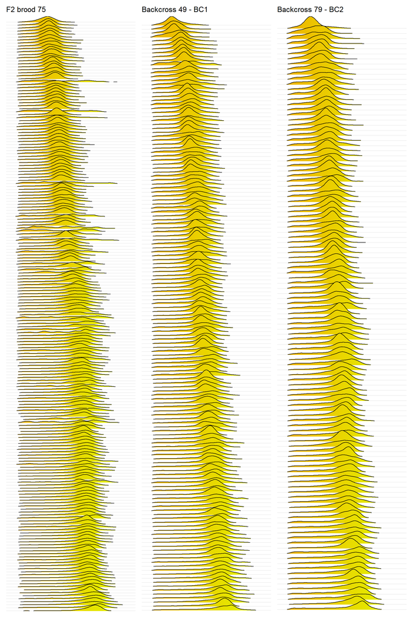

```r
joyplot_49 <- ggplot(b_data_49, aes(x = b_value, y = sample, fill = after_stat(x))) +
  geom_density_ridges_gradient(scale = 2.5, rel_min_height = 0.01, color = "black") +
  scale_fill_gradient(low = "#EFB001", high = "#DFFA00") +
  scale_x_continuous(breaks = 50)+
  theme_minimal() +
  theme(legend.position = "none",
  axis.title.y = element_blank(),
  axis.text.y  = element_blank(),
  axis.ticks.y = element_blank(),
  axis.line.y  = element_blank(),
  axis.line.x = element_blank(),
  axis.title.x = element_blank()
)+
  labs(
    title = "Backcross 49 - BC1",
    fill = "b*"
  )


joyplot_75 <- ggplot(b_data_75, aes(x = b_value, y = sample, fill = after_stat(x))) +
  geom_density_ridges_gradient(scale = 2.5, rel_min_height = 0.01, color = "black") +
  scale_fill_gradient(low = "#EFB001", high = "#DFFA00") +
  scale_x_continuous(breaks = 50)+
  theme_minimal() +
  theme(legend.position = "none",
  axis.title.y = element_blank(),
  axis.text.y  = element_blank(),
  axis.ticks.y = element_blank(),
  axis.line.y  = element_blank(),
  axis.line.x = element_blank(),
  axis.title.x = element_blank()
)+
  labs(
    title = "F2 brood 75",
    fill = "b*"
  )


joyplot_79 <- ggplot(b_data_79, aes(x = b_value, y = sample, fill = after_stat(x))) +
  geom_density_ridges_gradient(scale = 2.5, rel_min_height = 0.01, color = "black") +
  scale_fill_gradient(low = "#EFB001", high = "#DFFA00") +
  scale_x_continuous(breaks = 50)+
  theme_minimal() +
  theme(legend.position = "none",
  axis.title.y = element_blank(),
  axis.text.y  = element_blank(),
  axis.ticks.y = element_blank(),
  axis.line.y  = element_blank(),
  axis.line.x = element_blank(),
  axis.title.x = element_blank()
)+
  labs(
    title = "Backcross 79 - BC2",
    fill = "b*"
  )

final_joyplot <- joyplot_75 | joyplot_49 | joyplot_79
final_joyplot
```

Now that we have recreated the amazing joyplot with the three main populations, let’s figure out how to find the most extreme orange and yellow butterflies within them.

```r
# Combine everything
all_b_data <- bind_rows(
  b_data_49 %>% mutate(brood = "DFW_49"),
  b_data_75 %>% mutate(brood = "DFW_75"),
  b_data_79 %>% mutate(brood = "DFW_79")
)

# Find extremes
extremes <- all_b_data %>%
  group_by(sample, brood) %>%
  summarise(median_L = median(b_value, na.rm = TRUE), .groups = "drop") %>%
  arrange(desc(median_L))

# Most yellow butterfly (highest median L)
most_yellow       <- extremes[1, ]
most_yellow_file  <- paste0(most_yellow$sample, ".jpg")

# Most orange butterfly (lowest median L)
most_orange       <- extremes[nrow(extremes), ]
most_orange_file  <- paste0(most_orange$sample, ".jpg")

# Print nicely
cat("Most YELLOW butterfly (overall):\n")
```

```
Most YELLOW butterfly (overall):
```

```r
cat("   File:", most_yellow_file, "\n")
```

```
   File: 00_75_109_DFW.jpg.jpg
```

```r
cat("   Brood:", most_yellow$brood, "\n")
```

```
   Brood: DFW_75
```

```r
cat("   Median L =", round(most_yellow$median_L, 2), "\n\n")
```

```
   Median L = 88.05
```

```r
cat("Most ORANGE butterfly (overall):\n")
```

```
Most ORANGE butterfly (overall):
```

```r
cat("   File:", most_orange_file, "\n")
```

```
   File: 00-49-130_DFW.jpg.jpg
```

```r
cat("   Brood:", most_orange$brood, "\n")
```

```
   Brood: DFW_49
```

```r
cat("   Median L =", round(most_orange$median_L, 2), "\n")
```

```
   Median L = 74.7
```

```
From reference white:
To reference white: D65
```

```
Converting 10000 randomly selected pixel(s) from sRGB color space to Lab color space
```

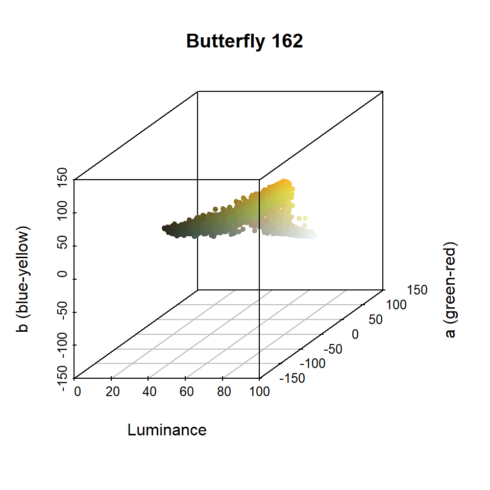

```r
yellow_3d <- Lab_plot(pop_files[["DFW_49"]][130])
```